# Diagnose Breast Cancer

## Creating Naive Bayes Classification

## Model 1

The Naive Bayes model will include the features age group, menopause, breast density, relatives with breast cancer, and invasive breast cancer. All which are the features from our hypothesis. By printing the mean of the features, we can see whether or not they will be relevant using Naive Bayes Classification. The most important feature in this group when it comes to predicting cancer is whether or not a patient has had cancer in the past.

```r
fit = naiveBayes(cancer_factor ~ age.group + menopause + breast.density + relatives.with.bc + invasive.bc, data = tr_dat)

print(fit$tables$menopause)
```

```
##            menopause
## Y                [,1]      [,2]
##   no cancer 0.8649800 0.3417489
##   cancer    0.8385446 0.3680551
```

```r
print(fit$tables$relatives.with.bc)
```

```
##            relatives.with.bc
## Y                [,1]      [,2]
##   no cancer 0.3961559 0.5918316
##   cancer    0.2723138 0.4902703
```

```r
print(fit$tables$invasive.bc)
```

```
##            invasive.bc
## Y                [,1]      [,2]
##   no cancer 0.0000000 0.0000000
##   cancer    0.7498579 0.4332179
```

## Analyzing Model 1

The confusion matrix shows that majority of the predictions were correct. Unfortunately, the model is not great because for 155 patients, it was predicted that they had no cancer when in fact they did. In an ideal model, it would be better to predict cancer when there is none because then all patients would be getting checked and not have a false positive.

```r
actual = te_dat$cancer_factor
predicted = predict(fit, newdata = te_dat)

confusion_matrix = table(actual, predicted)
TN = confusion_matrix[1,1]
FN = confusion_matrix[2,1]
FP = confusion_matrix[1,2]
TP = confusion_matrix[2,2]

confusion_matrix
```

```
##            predicted
## actual      no cancer cancer
##   no cancer     14588      0
##   cancer          155    482
```

The accuracy with the selected features is fairly high, but with data as sensitive as the one we have, we would like to have the highest accuracy.

```r
accuracy = mean(predicted == actual)
round(accuracy, 4)
```

```
## [1] 0.9898
```

This precision value shows that, from the first model, all our prediction with cancer were correct. As for our recall, we can see that the model predicted both items correctly seventy-five percent of the time.

```r
# precision = true positives / (true positives + false positives)
precision = TP/(TP+FP)

# recall =  true positives/ (true positives + false negatives)
recall = TP/(TP + FN)

paste("precision:", round(precision, 3))
```

```
## [1] "precision: 1"
```

```r
paste("recall:", round(recall, 3))
```

```
## [1] "recall: 0.757"
```

The double density plot shows that all the predictions for cancer were correct, but there is a margin of error when the no cancer prediction shows.

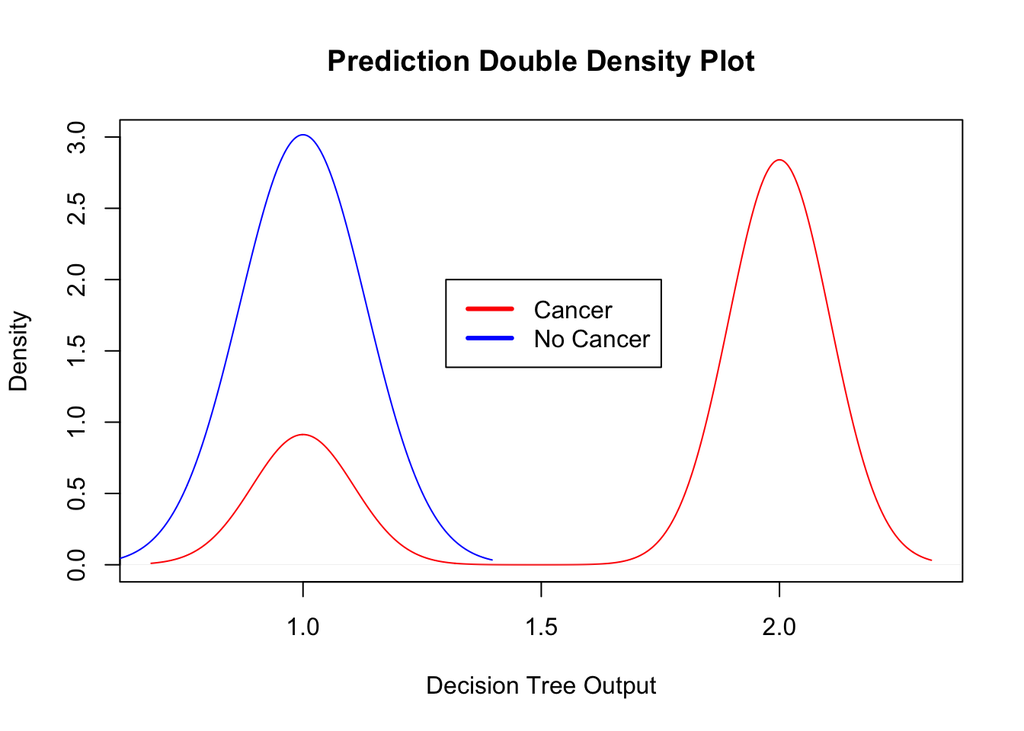

```r
plot(density(as.numeric(predicted[actual == "cancer"])), main = "Prediction Double Density Plot", xlab="Decision Tree Output", col="red", ylim=range(0:3))
lines(density(as.numeric(predicted[actual == "no cancer"])), col="blue")
legend(1.3,2, c("Cancer", "No Cancer"),col=c("red", "blue"), inset=0.05, lty=1, lwd=3)
```

## Model 2

Although the Naive Bayes classification does not guarantee that an incremented amount of features will improve the classifier, it could make better predictions if useful features are in use.

```r
fit = naiveBayes(cancer_factor ~ ., data = tr_dat)
print(fit$tables$invasive.bc)
```

```
##            invasive.bc
## Y                [,1]      [,2]
##   no cancer 0.0000000 0.0000000
##   cancer    0.7498579 0.4332179
```

## Analyzing Model 2

```r
actual = te_dat$cancer_factor
predicted = predict(fit, newdata = te_dat)

con_matrix = table(actual, predicted)
TN = confusion_matrix[1,1]
FN = confusion_matrix[2,1]
FP = confusion_matrix[1,2]
TP = confusion_matrix[2,2]

confusion_matrix
```

```
##            predicted
## actual      no cancer cancer
##   no cancer     14588      0
##   cancer          155    482
```

That data shows that the accuracy dropped by .2 percent.

```r
accuracy = mean(predicted == actual)
round(accuracy, 3)
```

```
## [1] 0.987
```

The overall recall for this model did not change.

```r
# precision = true positives / (true positives + false positives)
precision = TP/(TP+FP)

# recall =  true positives/ (true positives + false negatives)
recall = TP/(TP + FN)

paste("precision:", round(precision, 3))
```

```
## [1] "precision: 1"
```

```r
paste("recall:", round(recall, 3))
```

```
## [1] "recall: 0.757"
```

From this confusion matrix, the density of the error is almost at one percent.

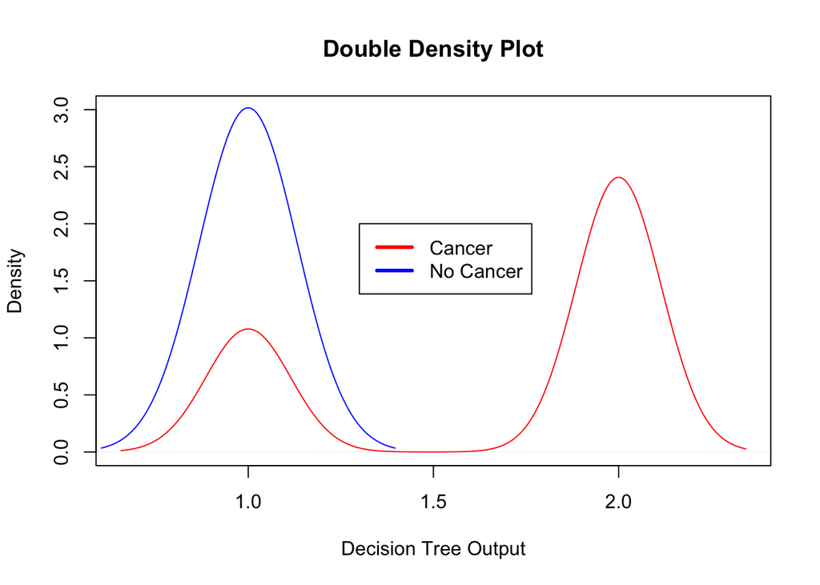

```r
plot(density(as.numeric(predicted[actual == "cancer"])), main = "Double Density Plot", xlab="Decision Tree Output", col="red", ylim=range(0:3))
lines(density(as.numeric(predicted[actual == "no cancer"])), col="blue")
legend(1.3,2, c("Cancer", "No Cancer"),col=c("red", "blue"), inset=0.05, lty=1, lwd=3)
```

## Model 3

In this last model, the feature, invasive breast cancer, is removed to see the prediction of breast cancer not taking under consideration previous conditions.

```r
fit = naiveBayes(cancer_factor ~ age.group + last.mammogram + age.first.birth + race, data = tr_dat)
```

## Analyzing Model 3

In this last model the feature invasive breast cancer is removed to see the prediction of breast cancer not taking under consideration previous conditions.

```r
fit = naiveBayes(cancer_factor ~ age.group + last.mammogram + age.first.birth + race, data = tr_dat)

# class(fit)
# summary(fit)
# print(fit)
```

```r
actual = te_dat$cancer_factor
predicted = predict(fit, newdata = te_dat)


con_matrix = table(actual, predicted)
TN = confusion_matrix[1,1]
FN = confusion_matrix[2,1]
FP = confusion_matrix[1,2]
TP = confusion_matrix[2,2]

confusion_matrix
```

```
##            predicted
## actual      no cancer cancer
##   no cancer     14588      0
##   cancer          155    482
```

The accuracy of the new confusion matrix is lowered than the second model’s confusion matrix. This demonstrates that the invasive cancer feature has an influence of raising the overall accuracy for predicting breast cancer. This also shows that even when more features added with the invasive cancer feature, the feature does not have any influence in raising or lowering the prediction accuracy. However, taking away the invasive cancer feature does lower the accuracy for predicting breast cancer.

```r
accuracy = mean(predicted == actual)
round(accuracy, 3)
```

```
## [1] 0.958
```

```r
# precision = true positives / (true positives + false positives)
precision = TP/(TP+FP)

# recall =  true positives/ (true positives + false negatives)
recall = TP/(TP + FN)

paste("precision:", round(precision, 3))
```

```
## [1] "precision: 1"
```

```r
paste("recall:", round(recall, 3))
```

```
## [1] "recall: 0.757"
```